# Problem Set 5

Matthew E. Aiello-Lammens

2018-02-22

**Please submit this homework as an R Markdown (Rmd) file.** See the introduction to [Problem Set 1](http://mlammens.github.io/ENS-623-Research-Stats/problem_sets/Problem-set-1.html) if you need more information about the Rmd format.

#### File name

Your file should use the following naming scheme

**`[last name]_ENS623_SP18_PS5.Rmd`**

For example,

`Lammens_ENS623_SP18_PS5.Rmd`

#### Grading note

Problem 1 and 3 are worth 10 points (partial credit given) and Problem 2 and the Bonus are worth 5 points.

# Problem 1 - Plotting relationships between variables

In class on Wednesday, I demonstrated how to use `ggplot2` to make an x-y scatter plot comparing `Sepal.Length` and `Petal.Length` in the `iris` data set.

Recall that you must first install `ggplot2` if you have not done so already:

```r
install.packages("ggplot2")
```

Then load it into your environment:

```r
library(ggplot2)
```

Then the code to create the actual plot looks like this:

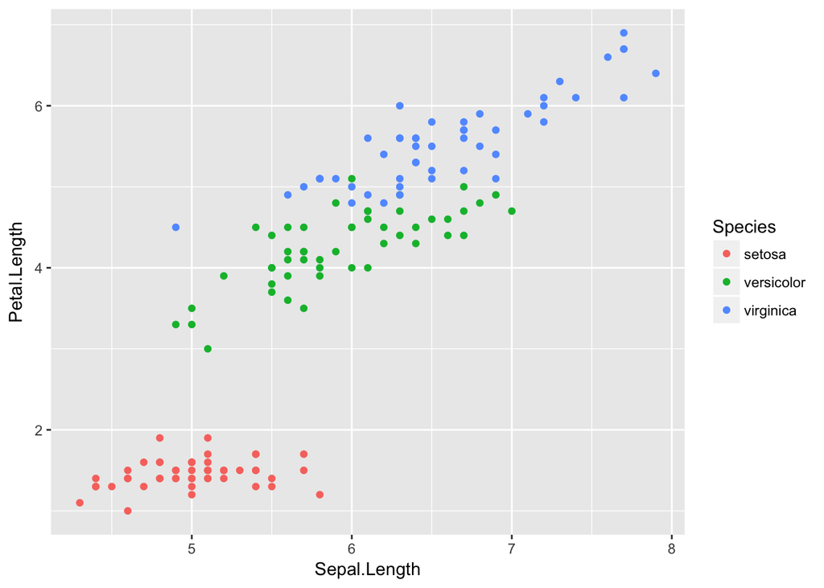

```r
data(iris)

ggplot(data = iris, aes( x = Sepal.Length, y = Petal.Length, colour = Species )) +
  geom_point()
```

I very briefly showed you that you can add the term `geom_smoth(method = "lm")` to add linear regression lines onto your plot, as such:

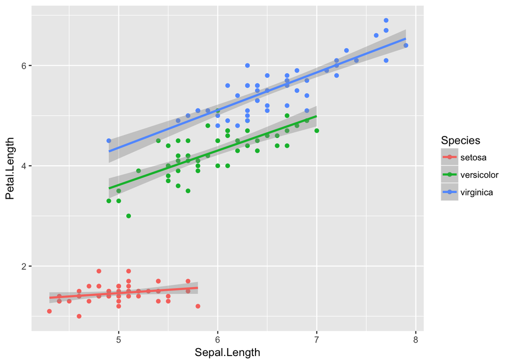

```r
ggplot(data = iris, aes( x = Sepal.Length, y = Petal.Length, colour = Species )) +
  geom_point() +
  geom_smooth(method = "lm")
```

**Use the code above, but replace `Petal.Length` with `Sepal.Width`. Make a new x-y scatter plot with linear regression lines. Describe how accounting for the three different species might influence how you interpret your data, in comparison to an x-y scatter plot where you do not seperate the species.**

*Hint:* You might want to make an x-y scatter plot that does not color the different species.

# Problem 2 - Working with syntax in `ggplot2`

Below are two code chunks, both which create histograms and density plots using the `iris` data set.

## Chunk 1

```r
ggplot() +
  geom_histogram(data = iris, aes(x = Petal.Length, y = ..density.., fill = Species),
                 position = "dodge") +
  geom_density(data = iris, aes(x = Petal.Length, colour = Species)) +
  theme_bw()
```

## Chunk 2

```r
ggplot(data = iris, aes(x = Petal.Length)) +
  geom_histogram( aes(y = ..density.., fill = Species),
                 position = "dodge") +
  geom_density( aes(colour = Species)) +
  theme_bw()
```

**Describe the differences between the code chunks.**

**Do Chunks 1 and 2 produce the same plots?**

**Based on the answers to the above two questions, what do you think the role of defining arguments in the `ggplot()` function is?**

## Bonus

How do you interpret the figure produced by the code below?

```r
ggplot(data = iris, aes(x = Petal.Length)) +
  geom_histogram( aes(y = ..density.., fill = Species),
                 position = "dodge") +
  #facet_grid( Species ~ . ) +
  geom_density() +
  theme_bw()
```

# Problem 3 - Systematic Review

Read the Pullin and Stewart 2006 article posted on BlackBoard. During our next class, we will discuss systematic reviews. In preparation for that discussion, write a reading response of about 200 words explaining the ways a systematic review of the literature differs from how you have approached writing reviews in the past (e.g., term papers, final papers, etc.).